# Chapter 6 Taxonomic composition

Per-sample relative abundance profiles (phylum → family → genus) and rollups by sex and broad environment. This chapter shows which clades dominate overall and how composition shifts across groups.

**Note:** Load all required data objects including genome counts, metadata, and color schemes.

```r
load("data/data.Rdata")
```

**Note:** Filter out sample EHI01340, recode environment names to readable format, and filter genome counts to only include valid samples.

```r
sample_metadata<- sample_metadata %>% filter(sample!="EHI01340")

sample_metadata <- sample_metadata%>%
  mutate(broad_environment = recode(broad_environment,
                          "1000221 - Temperate woodland" = "Temperate woodland",
                          "1000198 - Mixed forest" = "Mixed forest",
                          "1000218 - Xeric shrubland" = "Xeric shrubland",
                          "1000215 - Temperate shrubland" = "Temperate shrubland",
                          "1000245 - Cropland" = "Cropland"))

valid_samples <- sample_metadata$sample

genome_counts_filt <- genome_counts_filt %>%
  dplyr::select(genome, tidyselect::any_of(valid_samples))
```

**Note:** Define helper functions used throughout the analysis: `count_phyla_by_group` (counts phyla in filtered samples), `create_taxonomy_summary` (creates summary tables with relative abundances), and `calc_summary_stats` (calculates mean±SD statistics).

```r
# Helper function to count phyla by filtered group
count_phyla_by_group <- function(filter_var, filter_value, domain_filter = "d__Bacteria") {
  filtered_samples <- sample_metadata %>%
    filter(.data[[filter_var]] == filter_value) %>%
    pull(sample)

  filtered_genomes <- genome_counts_filt %>%
    column_to_rownames("genome") %>%
    select(all_of(filtered_samples)) %>%
    as.data.frame() %>%
    filter(rowSums(across(where(is.numeric))) > 0) %>%
    rownames_to_column("genome") %>%
    pull(genome)

  genome_metadata %>%
    filter(genome %in% filtered_genomes, domain == domain_filter) %>%
    distinct(phylum) %>%
    nrow()
}

# Helper function to create taxonomy summary tables
create_taxonomy_summary <- function(tax_level, group_vars) {
  # tax_level: "phylum", "family", or "genus"
  # group_vars: vector of additional grouping variables (e.g., c("broad_environment", "sex"))
  # Note: "sample" and tax_level are automatically included in grouping
  # For genus, phylum should come before genus in grouping order

  # Build group_by expression with explicit column order
  # For genus, ensure phylum comes before genus
  if (tax_level == "genus" && "phylum" %in% group_vars) {
    # Remove phylum from group_vars and insert it before genus
    group_vars_no_phylum <- group_vars[group_vars != "phylum"]
    group_expr <- c("sample", "phylum", tax_level, group_vars_no_phylum)
    # Column order for output: sample, phylum, genus, then other vars, then relabun
    col_order <- c("sample", "phylum", tax_level, group_vars_no_phylum, "relabun")
  } else {
    group_expr <- c("sample", tax_level, group_vars)
    # Column order for output: sample, tax_level, then other vars, then relabun
    col_order <- c("sample", tax_level, group_vars, "relabun")
  }

  result <- genome_counts_filt %>%
    mutate_at(vars(-genome), ~ . / sum(.)) %>%
    pivot_longer(-genome, names_to = "sample", values_to = "count") %>%
    left_join(sample_metadata, by = join_by(sample == sample)) %>%
    left_join(genome_metadata, by = join_by(genome == genome)) %>%
    group_by(across(all_of(group_expr))) %>%
    summarise(relabun = sum(count))

  # Reorder columns to match original order
  result %>% select(all_of(col_order))
}

# Helper function to calculate summary statistics by groups
calc_summary_stats <- function(data, tax_col, group_col = NULL, group_values = NULL) {
  # Calculate total statistics
  result <- data %>%
    group_by(across(all_of(tax_col))) %>%
    summarise(
      total_mean = mean(relabun * 100, na.rm = TRUE),
      total_sd = sd(relabun * 100, na.rm = TRUE),
      .groups = "drop"
    )

  # Add statistics for each group value if provided
  if (!is.null(group_col) && !is.null(group_values)) {
    for (val in group_values) {
      group_stats <- data %>%
        filter(.data[[group_col]] == val) %>%
        group_by(across(all_of(tax_col))) %>%
        summarise(
          mean_val = mean(relabun * 100, na.rm = TRUE),
          sd_val = sd(relabun * 100, na.rm = TRUE),
          .groups = "drop"
        )

      result <- result %>%
        left_join(group_stats, by = tax_col) %>%
        rename(!!str_c(val, "_mean") := mean_val, !!str_c(val, "_sd") := sd_val)
    }
  }

  # Format the output
  result <- result %>%
    mutate(Total = str_c(round(total_mean, 3), "±", round(total_sd, 3)))

  # Add formatted columns for each group value
  if (!is.null(group_col) && !is.null(group_values)) {
    for (val in group_values) {
      mean_col <- str_c(val, "_mean")
      sd_col <- str_c(val, "_sd")
      col_name <- str_replace_all(val, " ", "_")  # Convert spaces to underscores
      result[[col_name]] <- str_c(round(result[[mean_col]], 3), "±", round(result[[sd_col]], 3))
    }

    # Create vector of column names with underscores
    group_col_names <- str_replace_all(group_values, " ", "_")

    result %>%
      arrange(-total_mean) %>%
      select(all_of(tax_col), Total, all_of(group_col_names))
  } else {
    result %>%
      arrange(-total_mean) %>%
      select(all_of(tax_col), Total)
  }
}
```

## 6.1 Taxonomy overview

### 6.1.1 Phylum level

**Note:** Create stacked bar plot showing relative abundance of phyla per sample. Data is normalized using Total Sum Scaling (TSS), then joined with metadata and visualized as stacked bars colored by phylum.

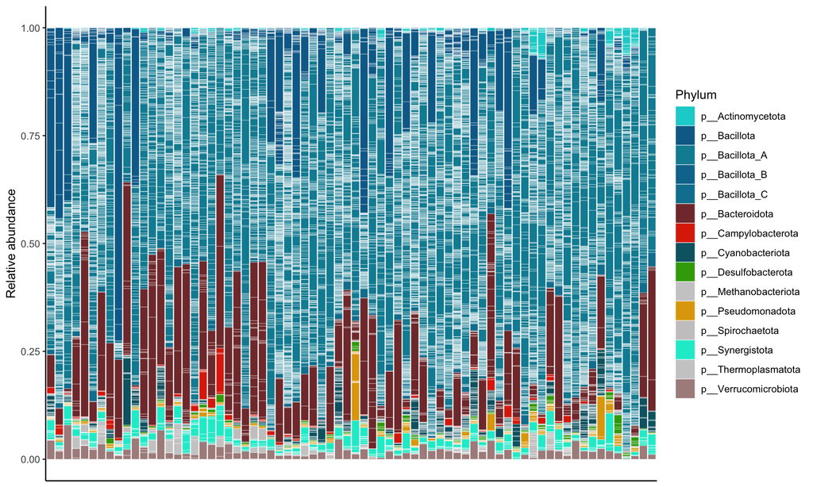

```r
genome_counts_filt %>%
  mutate_at(vars(-genome),~./sum(.)) %>% #apply TSS normalisation
  pivot_longer(-genome, names_to = "sample", values_to = "count") %>% #reduce to minimum number of columns
  left_join(., genome_metadata, by = join_by(genome == genome)) %>% #append genome metadata
  left_join(., sample_metadata, by = join_by(sample == sample)) %>% #append sample metadata
  filter(count > 0) %>% #filter 0 counts
  ggplot(., aes(x=sample,y=count, fill=phylum, group=phylum)) + #grouping enables keeping the same sorting of taxonomic units
    geom_bar(stat="identity", colour="white", linewidth=0.1) + #plot stacked bars with white borders
    scale_fill_manual(values=phylum_colors) +
    guides(fill = guide_legend(ncol = 1)) +
    theme(axis.text.x = element_blank(),
          axis.ticks.x = element_blank(),
          axis.title.x = element_blank(),
          panel.background = element_blank(),
          panel.border = element_blank(),
          panel.grid.major = element_blank(),
          panel.grid.minor = element_blank(),
          strip.background = element_rect(fill = "white"),
          strip.text = element_text(size = 12, lineheight = 0.6,face="bold"),
          axis.line = element_line(linewidth = 0.5, linetype = "solid", colour = "black")) +
   labs(fill="Phylum",y = "Relative abundance",x="Samples")
```

Relative abundance of microbiota phylum per sample

**Number of MAGs**

**Note:** Count and display the total number of Metagenome-Assembled Genomes (MAGs) in the dataset.

```
1817
```

**Number of bacteria phyla**

**Note:** Count and display the number of unique bacterial phyla present in the dataset.

```
13
```

**Number of Archaea phyla**

**Note:** Count and display the number of unique archaeal phyla present in the dataset.

```
2
```

*Phylum relative abundances*

**Note:** Create phylum-level summary table with relative abundances grouped by sample, phylum, broad_environment, and sex.

```r
phylum_summary <- create_taxonomy_summary("phylum", c("broad_environment", "sex"))
```

**Note:** Calculate summary statistics (mean±SD) for phylum relative abundances across all samples.

```r
calc_summary_stats(phylum_summary, "phylum")
```

```
## # A tibble: 15 × 2
##    phylum               Total
##    <chr>                <chr>
##  1 p__Bacillota_A       60.713±17.816
##  2 p__Bacteroidota      15.337±12.756
##  3 p__Bacillota         10.651±15.13
##  4 p__Synergistota      2.856±1.778
##  5 p__Cyanobacteriota   2.624±3.286
##  6 p__Verrucomicrobiota 2.074±1.467
##  7 p__Pseudomonadota    1.207±2.219
##  8 p__Bacillota_C       1.133±0.683
##  9 p__Thermoplasmatota  0.868±1.487
## 10 p__Campylobacterota  0.866±1.568
## 11 p__Actinomycetota    0.749±1.478
## 12 p__Desulfobacterota  0.681±0.697
## 13 p__Spirochaetota     0.189±0.607
## 14 p__Methanobacteriota 0.03±0.061
## 15 p__Bacillota_B       0.02±0.043
```

phylum relative abundance - total

**Note:** Create jitter plot showing relative abundance distribution for the top 20 phyla. Phyla are ordered by mean abundance and colored by phylum.

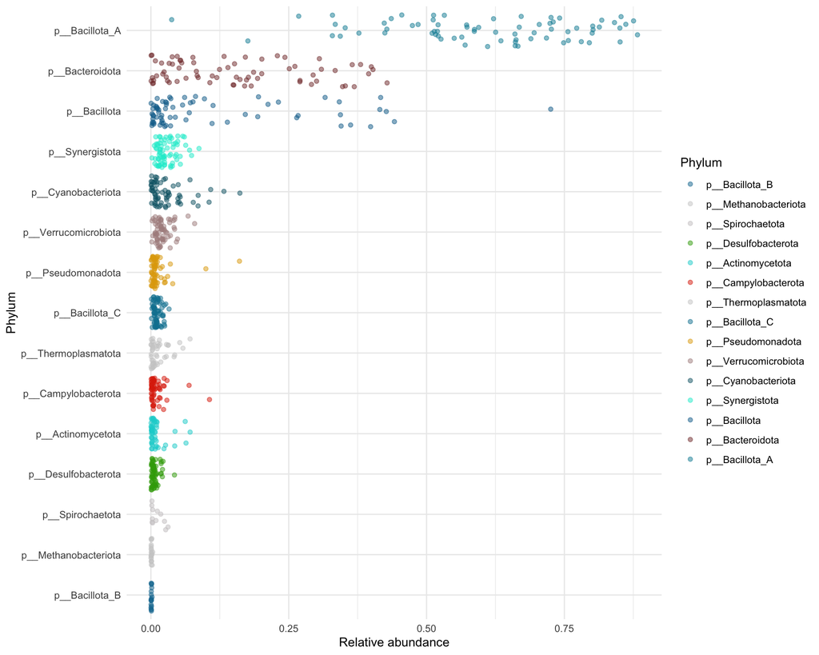

```r
phylum_arrange <- phylum_summary %>%
    group_by(phylum) %>%
    summarise(mean=mean(relabun), .groups = "drop") %>%
    arrange(-mean) %>%
    select(phylum) %>%
    pull()

phylum_summary %>%
    filter(phylum %in% phylum_arrange[1:20]) %>%
    mutate(phylum=factor(phylum,levels=rev(phylum_arrange[1:20]))) %>%
    filter(relabun > 0) %>%
    ggplot(aes(x=relabun, y=phylum, group=phylum, color=phylum)) +
        scale_color_manual(values=phylum_colors) +
        geom_jitter(alpha=0.5) +
        theme_minimal() +
        labs(y="Phylum", x="Relative abundance", color="Phylum")
```

**Bacteria phyla in individuals from females**

**Note:** Count and display the number of bacterial phyla found in samples from female individuals.

```
12
```

**Bacteria phyla in individuals from males**

**Note:** Count and display the number of bacterial phyla found in samples from male individuals.

```
13
```

phylum relative abundance - sex

**Note:** Calculate summary statistics (mean±SD) for phylum relative abundances grouped by sex (Female and Male).

```r
calc_summary_stats(phylum_summary, "phylum", "sex", c("Female", "Male"))
```

```
## # A tibble: 15 × 4
##    phylum               Total         Female        Male
##    <chr>                <chr>         <chr>         <chr>
##  1 p__Bacillota_A       60.713±17.816 59.012±21.422 63.183±14.871
##  2 p__Bacteroidota      15.337±12.756 14.648±11.721 13.48±11.248
##  3 p__Bacillota         10.651±15.13  12.942±17.914 10.184±13.886
##  4 p__Synergistota      2.856±1.778   2.967±1.775   2.65±1.655
##  5 p__Cyanobacteriota   2.624±3.286   2.659±3.026   2.965±3.089
##  6 p__Verrucomicrobiota 2.074±1.467   2.067±1.288   2.274±1.798
##  7 p__Pseudomonadota    1.207±2.219   1.234±1.949   0.951±0.784
##  8 p__Bacillota_C       1.133±0.683   1.37±0.897    1.025±0.503
##  9 p__Thermoplasmatota  0.868±1.487   0.766±1.708   0.723±1.287
## 10 p__Campylobacterota  0.866±1.568   0.53±0.754    0.991±1.341
## 11 p__Actinomycetota    0.749±1.478   1.128±2.008   0.609±1.113
## 12 p__Desulfobacterota  0.681±0.697   0.615±0.587   0.652±0.486
## 13 p__Spirochaetota     0.189±0.607   0±0           0.277±0.83
## 14 p__Methanobacteriota 0.03±0.061    0.044±0.069   0.013±0.025
## 15 p__Bacillota_B       0.02±0.043    0.018±0.041   0.023±0.05
```

**Bacteria phyla in individuals from Temperate woodland**

**Note:** Count and display the number of bacterial phyla found in samples from Temperate woodland environment.

```
13
```

**Bacteria phyla in individuals from Xeric shrubland**

**Note:** Count and display the number of bacterial phyla found in samples from Xeric shrubland environment.

```
13
```

**Bacteria phyla in individuals from Mixed forest**

**Note:** Count and display the number of bacterial phyla found in samples from Mixed forest environment.

```
11
```

**Bacteria phyla in individuals from Cropland**

**Note:** Count and display the number of bacterial phyla found in samples from Cropland environment.

```
12
```

phylum relative abundance - broad environment clusters

**Note:** Calculate summary statistics (mean±SD) for phylum relative abundances grouped by broad environment type (all five environment types).

```r
calc_summary_stats(
  phylum_summary,
  "phylum",
  "broad_environment",
  c("Cropland", "Mixed forest", "Xeric shrubland", "Temperate woodland", "Temperate shrubland")
) %>%
  select(phylum, Total, Cropland, Temperate_woodland, Mixed_forest, Xeric_shrubland, Temperate_shrubland)
```

```
## # A tibble: 15 × 7
##    phylum      Total Cropland Temperate_woodland Mixed_forest Xeric_shrubland Temperate_shrubland
##    <chr>       <chr> <chr>    <chr>              <chr>        <chr>           <chr>
##  1 p__Bacillo… 60.7… 58.875±… 63.149±17.119      34.394±18.0… 57.552±18.161   79.486±7.888
##  2 p__Bactero… 15.3… 15.481±… 14.668±12.774      10.876±11.5… 26.428±17.109   10.537±8.905
##  3 p__Bacillo… 10.6… 14.427±… 8.561±12.074       38.211±25.4… 2.336±1.65      0.257±0.209
##  4 p__Synergi… 2.85… 2.215±1… 2.877±1.824        4.395±1.665  3.122±2.054     1.79±0.33
##  5 p__Cyanoba… 2.62… 2.238±2… 2.907±3.671        3.894±2.743  0.326±0.377     2.088±2.893
##  6 p__Verruco… 2.07… 1.534±0… 1.998±1.116        4.934±2.723  2.134±0.872     0.355±0.614
##  7 p__Pseudom… 1.20… 0.769±0… 1.405±2.689        0.769±0.157  0.558±0.257     1.752±1.564
##  8 p__Bacillo… 1.13… 1.154±0… 1.138±0.762        1.145±0.526  0.894±0.286     1.427±0.69
##  9 p__Thermop… 0.86… 1.874±2… 0.475±1.01         0.209±0.204  2.817±0.979     0.542±0.939
## 10 p__Campylo… 0.86… 0.776±0… 0.746±1.234        0.611±0.499  2.261±4.129     0.71±0.756
## 11 p__Actinom… 0.74… 0.108±0… 1.036±1.75         0.286±0.281  0.278±0.522     0.31±0.536
## 12 p__Desulfo… 0.68… 0.483±0… 0.773±0.768        0.275±0.289  0.653±0.615     0.687±0.196
## 13 p__Spiroch… 0.18… 0±0      0.211±0.697        0±0          0.62±0.635      0±0
## 14 p__Methano… 0.03… 0.036±0… 0.037±0.071        0±0          0±0             0±0
## 15 p__Bacillo… 0.02… 0.032±0… 0.017±0.045        0±0          0.022±0.028     0.059±0.056
```

### 6.1.2 Family

*Family summary grouped by sex*

**Note:** Create family-level summary table with relative abundances grouped by sample, family, broad_environment, and sex. Then calculate summary statistics grouped by sex.

```r
family_summary <- create_taxonomy_summary("family", c("broad_environment", "sex"))
calc_summary_stats(family_summary, "family", "sex", c("Female", "Male"))
```

```
## # A tibble: 52 × 4
##    family                     Total         Female        Male
##    <chr>                      <chr>         <chr>         <chr>
##  1 f__Lachnospiraceae         28.205±9.998  29.818±13.448 28.926±7.093
##  2 f__Oscillospiraceae        11.223±8.158  8.451±7.695   11.752±6.237
##  3 f__Bacteroidaceae          10.696±11.055 9.231±9.11    9.336±9.589
##  4 f__CAG-288                 8.635±15.251  11.469±18.156 7.94±13.683
##  5 f__Borkfalkiaceae          7.439±5.295   7.529±6.085   7.343±4.351
##  6 f__Ruminococcaceae         5.429±4.762   5.14±3.989    6.359±5.72
##  7 f__CAG-508                 4.042±4.359   3.495±4.278   4.605±4.655
##  8 f__Dethiosulfovibrionaceae 2.454±1.626   2.599±1.648   2.294±1.494
##  9 f__Muribaculaceae          2.053±4.249   2.968±5.555   1.326±2.19
## 10 f__UBA932                  1.966±3.772   1.695±3.403   2.367±3.922
## # ℹ 42 more rows
```

**Note:** Create jitter plot showing relative abundance distribution for the top 20 families, faceted by sex. Families are colored by their phylum and ordered by mean abundance.

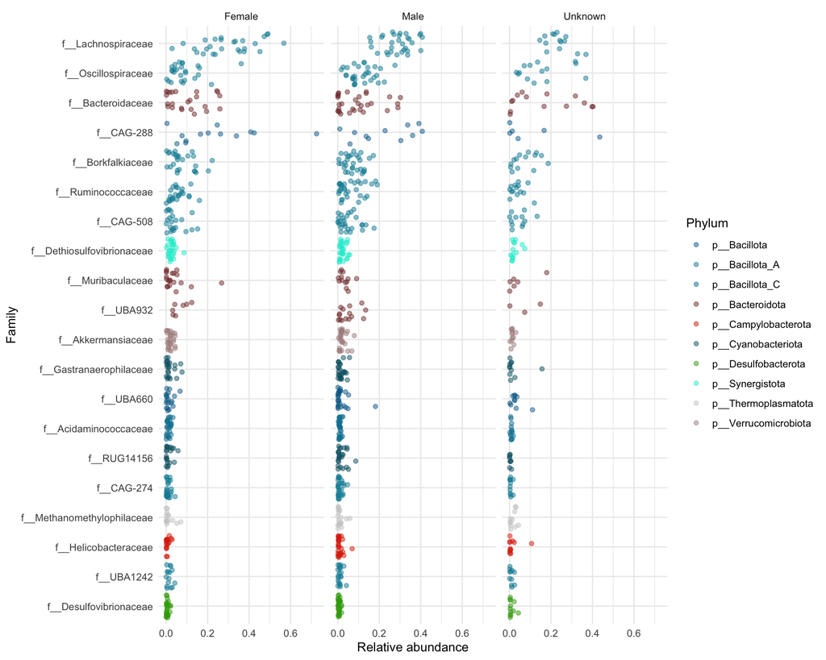

```r
family_arrange <- family_summary %>%
    group_by(family) %>%
    summarise(mean=mean(relabun), .groups = "drop") %>%
    arrange(-mean) %>%
    select(family) %>%
    pull()

family_phylum_map <- genome_metadata %>%
  dplyr::count(family, phylum, name = "n") %>%
  dplyr::group_by(family) %>%
  dplyr::slice_max(n, n = 1, with_ties = FALSE) %>%
  dplyr::ungroup() %>%
  dplyr::select(family, phylum)

# Per sex
family_summary %>%
    left_join(family_phylum_map, by = "family") %>%
    filter(family %in% family_arrange[1:20]) %>%
    mutate(family=factor(family,levels=rev(family_arrange[1:20]))) %>%
    filter(relabun > 0) %>%
    ggplot(aes(x=relabun, y=family, group=family, color=phylum)) +
        scale_color_manual(values=phylum_colors) +
        geom_jitter(alpha=0.5) +
        facet_grid(.~sex)+
        theme_minimal() +
        labs(y="Family", x="Relative abundance", color="Phylum")
```

*family relative abundance - broad environment clusters*

**Note:** Calculate summary statistics (mean±SD) for family relative abundances grouped by broad environment type (all five environment types).

```r
calc_summary_stats(
  family_summary,
  "family",
  "broad_environment",
  c("Cropland", "Mixed forest", "Xeric shrubland", "Temperate woodland", "Temperate shrubland")
) %>%
  select(family, Total, Cropland, Temperate_woodland, Mixed_forest, Xeric_shrubland, Temperate_shrubland)
```

```
## # A tibble: 52 × 7
##    family      Total Cropland Temperate_woodland Mixed_forest Xeric_shrubland Temperate_shrubland
##    <chr>       <chr> <chr>    <chr>              <chr>        <chr>           <chr>
##  1 f__Lachnos… 28.2… 25.865±… 29.657±10.487      22.929±12.4… 22.276±6.399    34.701±9.127
##  2 f__Oscillo… 11.2… 6.852±2… 12.307±8.693       4.256±3.422  17.81±7.479     8.71±5.012
##  3 f__Bactero… 10.6… 9.816±5… 9.817±11.399       9.473±10.239 22.416±13.948   6.285±5.473
##  4 f__CAG-288  8.63… 11.701±… 6.449±11.978       37.695±25.73 0.245±0.538     0±0
##  5 f__Borkfal… 7.43… 11.275±… 7.088±5.26         3.208±2.553  5.841±3.717     9.122±1.512
##  6 f__Ruminoc… 5.42… 6.017±5… 5.389±4.49         1.722±1.147  3.322±2.259     14.296±4.215
##  7 f__CAG-508  4.04… 4.664±4… 4.107±4.212        0.146±0.267  3.826±3.273     7.677±8.499
##  8 f__Dethios… 2.45… 2.049±1… 2.405±1.661        3.993±1.662  2.626±1.872     1.79±0.33
##  9 f__Muribac… 2.05… 2.813±5… 2.341±4.499        0.386±0.863  0±0             1.634±2.829
## 10 f__UBA932   1.96… 2.294±3… 1.763±3.655        0.915±2.046  3.7±6.208       2.21±3.828
## # ℹ 42 more rows
```

**Note:** Create jitter plot showing relative abundance distribution for the top 20 families, faceted by broad environment. Families are colored by their phylum and ordered by mean abundance.

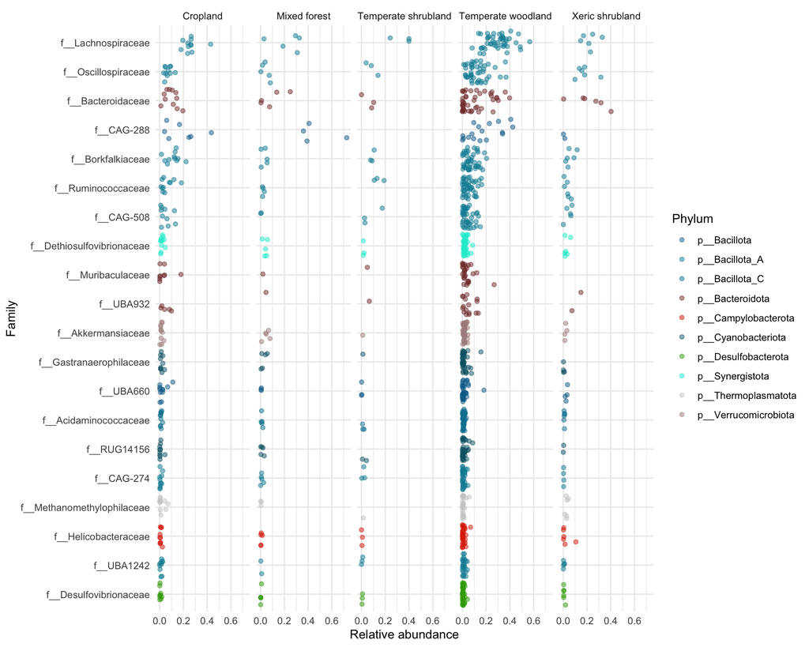

```r
family_arrange <- family_summary %>%
    group_by(family) %>%
    summarise(mean=mean(relabun), .groups = "drop") %>%
    arrange(-mean) %>%
    select(family) %>%
    pull()

# Per environment
family_summary %>%
    left_join(family_phylum_map, by = "family") %>%
    filter(family %in% family_arrange[1:20]) %>%
    mutate(family=factor(family,levels=rev(family_arrange[1:20]))) %>%
    filter(relabun > 0) %>%
    ggplot(aes(x=relabun, y=family, group=family, color=phylum)) +
        scale_color_manual(values=phylum_colors) +
        geom_jitter(alpha=0.5) +
        facet_grid(.~broad_environment)+
        theme_minimal() +
        labs(y="Family", x="Relative abundance", color="Phylum")
```

### 6.1.3 Genus level

*** Percentage of genera in each group of sex***

**Note:** Create genus-level summary table with relative abundances grouped by sample, phylum, genus, and sex.

```r
genus_summary <- create_taxonomy_summary("genus", c("phylum", "sex"))
calc_summary_stats(genus_summary, "genus", "sex", c("Female", "Male")) %>%
  select(genus, Total, Male, Female)
```

```
## # A tibble: 173 × 4
##    genus            Total        Male        Female
##    <chr>            <chr>        <chr>       <chr>
##  1 g__Prevotella    9.081±10.534 6.761±8.201 8.435±8.906
##  2 g__Enterosoma    8.635±15.251 7.94±13.683 11.469±18.156
##  3 g__Coproplasma   6.807±5.002  6.852±4.084 6.752±5.903
##  4 g__RGIG6307      5.319±4.84   6.178±5.285 4.467±5.172
##  5 g__Onthomonas    4.353±3.228  5.021±2.992 3.351±2.586
##  6 g__Ventrimonas   4.342±5.43   3.935±3.668 6.022±7.312
##  7 g__Eubacterium_I 3.269±2.549  3.336±1.804 3.328±2.91
##  8 g__Choladousia   2.622±1.668  3.109±1.545 2.266±1.754
##  9 g__Faeciplasma   2.6±3.197    3.338±3.991 2.463±2.538
## 10 g__Agathobacter  2.501±2.807  2.548±1.862 2.905±3.867
## # ℹ 163 more rows
```

**Note:** Create jitter plot showing relative abundance distribution for all genera, faceted by sex. Genera are colored by phylum and ordered by mean abundance. Smaller font size is used for y-axis labels to accommodate many genera.

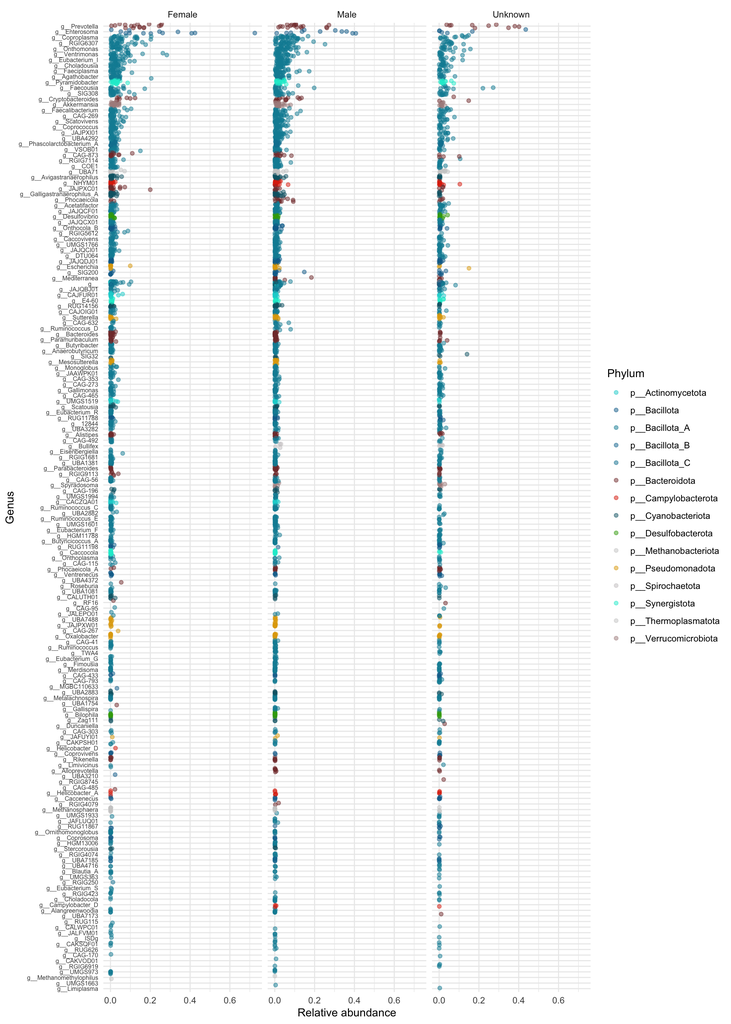

```r
genus_summary_sort <- genus_summary %>%
    group_by(genus) %>%
    summarise(mean=mean(relabun, na.rm=T),sd=sd(relabun, na.rm=T)) %>%
    arrange(-mean)

genus_summary %>%
  mutate(genus=factor(genus, levels=rev(genus_summary_sort %>% pull(genus)))) %>%
  filter(relabun > 0) %>%
  ggplot(aes(x=relabun, y=genus, group=genus, color=phylum)) +
  scale_color_manual(values=phylum_colors) +
  geom_jitter(alpha=0.5) +
  facet_grid(.~sex)+
  theme_minimal() +
  theme(axis.text.y = element_text(size=6))+
  labs(y="Genus", x="Relative abundance", color="Phylum")
```

*** Percentage of genera in each group of broad environment clusters***

**Note:** Calculate summary statistics (mean±SD) for genus relative abundances grouped by broad environment type (all five environment types).

```r
genus_summary <- create_taxonomy_summary("genus", c("phylum", "broad_environment"))
calc_summary_stats(
  genus_summary,
  "genus",
  "broad_environment",
  c("Cropland", "Mixed forest", "Xeric shrubland", "Temperate woodland", "Temperate shrubland")
) %>%
  select(genus, Total, Cropland, Temperate_woodland, Mixed_forest, Xeric_shrubland, Temperate_shrubland)
```

```
## # A tibble: 173 × 7
##    genus       Total Cropland Temperate_woodland Mixed_forest Xeric_shrubland Temperate_shrubland
##    <chr>       <chr> <chr>    <chr>              <chr>        <chr>           <chr>
##  1 g__Prevote… 9.08… 9.381±5… 8.141±10.756       4.235±6.183  21.397±13.482   6.134±5.358
##  2 g__Enteros… 8.63… 11.701±… 6.449±11.978       37.695±25.73 0.245±0.538     0±0
##  3 g__Copropl… 6.80… 10.681±… 6.328±4.94         3.196±2.54   5.313±3.765     9.122±1.512
##  4 g__RGIG6307 5.31… 4.127±2… 5.707±5.151        0.477±0.289  6.745±2.756     8.811±9.275
##  5 g__Onthomo… 4.35… 3.628±2… 4.237±3.041        2.906±2.533  7.746±5.474     4.468±2.407
##  6 g__Ventrim… 4.34… 3.449±4… 4.925±6.094        5.197±3.825  0.795±0.458     4.16±2.706
##  7 g__Eubacte… 3.26… 2.489±3… 3.597±2.571        2.763±2.006  2.887±1.925     2.589±0.584
##  8 g__Cholado… 2.62… 2.029±0… 2.638±1.7          1.956±1.192  2.869±1.766     5.168±2.012
##  9 g__Faecipl… 2.6±… 3.158±4… 2.748±3.049        1.153±0.718  0.746±1.353     4.357±0.705
## 10 g__Agathob… 2.50… 1.917±2… 2.575±3.063        2.888±1.871  1.333±1.002     5.163±3.516
## # ℹ 163 more rows
```

**Note:** Create jitter plot showing relative abundance distribution for all genera, faceted by broad environment. Genera are colored by phylum and ordered by mean abundance. Smaller font size is used for y-axis labels to accommodate many genera.

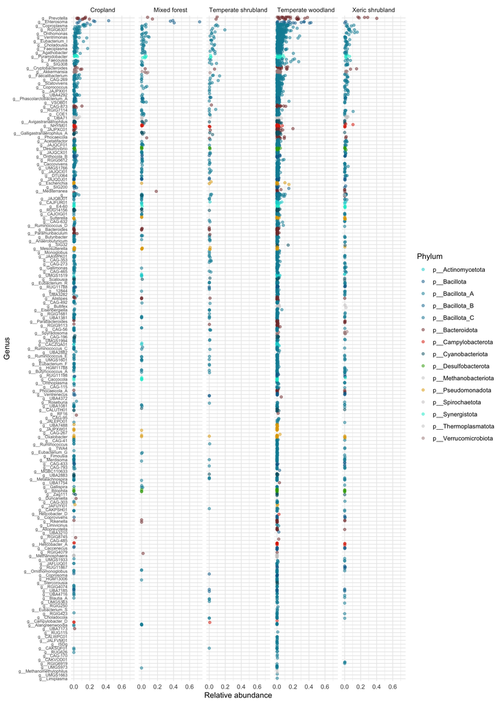

```r
# Recreate genus_summary with broad_environment to ensure it's available
genus_summary <- create_taxonomy_summary("genus", c("phylum", "broad_environment"))

# Verify broad_environment column exists and has data
if (!"broad_environment" %in% names(genus_summary)) {
  stop("Error: broad_environment column is missing from genus_summary. Columns are: ", paste(names(genus_summary), collapse=", "))
}

# Check if broad_environment has any non-NA values
if (all(is.na(genus_summary$broad_environment))) {
  stop("Error: broad_environment column exists but contains only NA values")
}

genus_summary_sort <- genus_summary %>%
    group_by(genus) %>%
    summarise(mean=mean(relabun, na.rm=T),sd=sd(relabun, na.rm=T)) %>%
    arrange(-mean)

# Create plot data ensuring broad_environment is explicitly included
plot_data <- genus_summary %>%
  filter(relabun > 0) %>%
  mutate(genus=factor(genus, levels=rev(genus_summary_sort %>% pull(genus))))

# Verify broad_environment is still in plot_data
if (!"broad_environment" %in% names(plot_data)) {
  stop("Error: broad_environment column lost during data preparation")
}

plot_data %>%
  ggplot(aes(x=relabun, y=genus, group=genus, color=phylum)) +
  scale_color_manual(values=phylum_colors) +
  geom_jitter(alpha=0.5) +
  facet_grid(.~broad_environment)+
  theme_minimal() +
  theme(axis.text.y = element_text(size=6))+
  labs(y="Genus", x="Relative abundance", color="Phylum")
```

**Number of MAGs without genera-level annotation**

**Note:** Count and display the number of MAGs that lack genus-level annotation (where genus == “g__“).

```
84
```

**Note:** Calculate and display the percentage of MAGs without genus-level annotation, broken down by phylum. Shows both count and percentage per phylum.

| phylum | count_nogene | count_total | percentage |
| --- | --- | --- | --- |
| p__Actinomycetota | 5 | 25 | 20.000000 |
| p__Bacillota | 3 | 94 | 3.191489 |
| p__Bacillota_A | 71 | 1440 | 4.930556 |
| p__Bacteroidota | 1 | 71 | 1.408451 |
| p__Cyanobacteriota | 3 | 82 | 3.658537 |
| p__Spirochaetota | 1 | 4 | 25.000000 |

**Percentage of MAGs without genus-level annotation**

**Note:** Calculate and display the overall percentage of MAGs in the dataset that lack genus-level annotation.

```
4.623005
```

**Number of MAGs without species-level annotation**

**Note:** Count and display the number of MAGs that lack species-level annotation (where species == “s__“).

```
1547
```

**Note:** Calculate and display statistics for MAGs without species-level annotation, broken down by phylum. Shows count, percentage without species annotation, and percentage with species annotation per phylum.

| phylum | count_nospecies | count_total | species_annotated | percentage | percentage_species |
| --- | --- | --- | --- | --- | --- |
| p__Actinomycetota | 25 | 25 | 0 | 100.00000 | 0.000000 |
| p__Bacillota | 93 | 94 | 1 | 98.93617 | 1.063830 |
| p__Bacillota_A | 1211 | 1440 | 229 | 84.09722 | 15.902778 |
| p__Bacillota_B | 1 | 1 | 0 | 100.00000 | 0.000000 |
| p__Bacillota_C | 7 | 7 | 0 | 100.00000 | 0.000000 |
| p__Bacteroidota | 53 | 71 | 18 | 74.64789 | 25.352113 |
| p__Campylobacterota | 13 | 15 | 2 | 86.66667 | 13.333333 |
| p__Cyanobacteriota | 74 | 82 | 8 | 90.24390 | 9.756098 |
| p__Desulfobacterota | 8 | 8 | 0 | 100.00000 | 0.000000 |
| p__Methanobacteriota | 1 | 1 | 0 | 100.00000 | 0.000000 |
| p__Pseudomonadota | 24 | 34 | 10 | 70.58824 | 29.411765 |
| p__Spirochaetota | 4 | 4 | 0 | 100.00000 | 0.000000 |
| p__Synergistota | 17 | 17 | 0 | 100.00000 | 0.000000 |
| p__Thermoplasmatota | 11 | 12 | 1 | 91.66667 | 8.333333 |
| p__Verrucomicrobiota | 5 | 6 | 1 | 83.33333 | 16.666667 |

**Percentage of MAGs without species-level annotation**

**Note:** Calculate and display the overall percentage of MAGs in the dataset that lack species-level annotation.

```
85.14034
```